# AIS - показатели крови и антропометрии элитных спортсменов

## Описание данных

В качестве задания для упражнений по книге **Джорджа Маунта "Погружение в аналитику данных"**, Санкт_Петербург, "БХВ-Петербург", 2024, используем классический датасет **AIS (Australian Institute of Sport)**, в котором собраны показатели крови и параметры тела элитных спортсменов.

**Расшифровка сокращений:**

**Показатели крови:**

- rcc (Red Cell Count) — количество эритроцитов (красных кровяных телец)
- wcc (White Cell Count) — количество лейкоцитов (белых кровяных телец)
- hc (Hematocrit) — гематокрит (доля объёма крови, которую занимают эритроциты)
- hg (Hemoglobin) — уровень гемоглобина
- ferr (Ferritin) — ферритин (показывает запасы железа в организме)

**Антропометрия и состав тела:**

- bmi (Body Mass Index) — ИМТ (индекс массы тела: вес / рост²)
- ssf (Sum of Skinfolds) — сумма кожных складок (используется для оценки подкожного жира)
- pcBfat (Percent Body Fat) — процент жира в организме
- lbm (Lean Body Mass) — безжировая масса тела (мышцы, кости, органы)
- ht (Height) — рост спортсмена (обычно в см)
- wt (Weight) — вес спортсмена (кг)

**Категории:**

- sex — пол спортсмена.
- sport — вид спорта, которым занимается атлет.

## Задание

EDA

1. Зависимость количества эритроциов (rcc) от пола (sex).
2. Зависимость показателей гемоглобина (hg) от пола (sex).
3. Построить матрицу корреляции значимых переменных в наборе данных.
4. Зависимость количества эритроцитов (rcc) от гематокрита (hc).
5. Визуализировать зависимость между ростом (ht) и весом (wt).
6. Влияние вида спорта (sport) на безжировую массу тела (lbm).
7. Показать средний индекс массы тела (bmi) для разных видов спорта.

Machine Learning

- Сравнить два алгоритма машинного обучения

## Загрузка библиотек

```python
# Загружаем библиотеку pandas
import pandas as pd
```

```python
# Загружаем библиотеки для визуализации данных
import matplotlib.pyplot as plt
import seaborn as sns
```

```python
# Уменьшение разрешения DPI для графиков
plt.rcParams['figure.dpi'] = 72
```

```python
import scipy.stats as stats
import numpy as np
```

```python
# Загружаем библиотеку для расчёта коэффициента корреляции phi_k
import phik
from phik import phik_matrix
from phik.report import plot_correlation_matrix
```

```python
#для реализации алгоритмов машинного обучения.
from sklearn.model_selection import train_test_split
from sklearn.linear_model import LinearRegression
from sklearn.metrics import mean_absolute_error, mean_squared_error, r2_score
from sklearn.ensemble import RandomForestRegressor
```

## Загрузка и предобработка данных

```python
try:
    df_ais = pd.read_csv('datasets/ais.csv')
    display('Файл загружен в датафрейм')
except:
    display('Ошибка при загрузке файла')
```

```
'Файл загружен в датафрейм'
```

```python
df_ais.info()
```

```
<class 'pandas.core.frame.DataFrame'>
RangeIndex: 202 entries, 0 to 201
Data columns (total 13 columns):
 #   Column  Non-Null Count  Dtype
---  ------  --------------  -----
 0   rcc     202 non-null    object
 1   wcc     202 non-null    object
 2   hc      202 non-null    object
 3   hg      202 non-null    object
 4   ferr    202 non-null    int64
 5   bmi     202 non-null    object
 6   ssf     202 non-null    object
 7   pcBfat  202 non-null    object
 8   lbm     202 non-null    object
 9   ht      202 non-null    object
 10  wt      202 non-null    object
 11  sex     202 non-null    object
 12  sport   202 non-null    object
dtypes: int64(1), object(12)
memory usage: 20.6+ KB
```

```python
df_ais.head()
```

|  | rcc | wcc | hc | hg | ferr | bmi | ssf | pcBfat | lbm | ht | wt | sex | sport |
| --- | --- | --- | --- | --- | --- | --- | --- | --- | --- | --- | --- | --- | --- |
| 0 | 3,96 | 7,5 | 37,5 | 12,3 | 60 | 20,56 | 109,1 | 19,75 | 63,32 | 195,9 | 78,9 | f | B_Ball |
| 1 | 4,41 | 8,3 | 38,2 | 12,7 | 68 | 20,67 | 102,8 | 21,3 | 58,55 | 189,7 | 74,4 | f | B_Ball |
| 2 | 4,14 | 5 | 36,4 | 11,6 | 21 | 21,86 | 104,6 | 19,88 | 55,36 | 177,8 | 69,1 | f | B_Ball |
| 3 | 4,11 | 5,3 | 37,3 | 12,6 | 69 | 21,88 | 126,4 | 23,66 | 57,18 | 185 | 74,9 | f | B_Ball |
| 4 | 4,45 | 6,8 | 41,5 | 14 | 29 | 18,96 | 80,3 | 17,64 | 53,2 | 184,6 | 64,6 | f | B_Ball |

Видим, что числовые данные находятся в текстовом формате и с запятыми вместо точек. Преобразуем формат столбцов в числовой.

```python
cols = ['rcc','wcc','hc','hg','bmi','ssf','pcBfat','lbm','ht','wt']
# regex=True работает сразу со всем DataFrame или списком колонок, даже если там есть пропуски (NaN)
df_ais[cols] = df_ais[cols].replace(',', '.', regex=True).astype(float)
```

```python
df_ais.info()
```

```
<class 'pandas.core.frame.DataFrame'>
RangeIndex: 202 entries, 0 to 201
Data columns (total 13 columns):
 #   Column  Non-Null Count  Dtype
---  ------  --------------  -----
 0   rcc     202 non-null    float64
 1   wcc     202 non-null    float64
 2   hc      202 non-null    float64
 3   hg      202 non-null    float64
 4   ferr    202 non-null    int64
 5   bmi     202 non-null    float64
 6   ssf     202 non-null    float64
 7   pcBfat  202 non-null    float64
 8   lbm     202 non-null    float64
 9   ht      202 non-null    float64
 10  wt      202 non-null    float64
 11  sex     202 non-null    object
 12  sport   202 non-null    object
dtypes: float64(10), int64(1), object(2)
memory usage: 20.6+ KB
```

```python
df_ais.head()
```

|  | rcc | wcc | hc | hg | ferr | bmi | ssf | pcBfat | lbm | ht | wt | sex | sport |
| --- | --- | --- | --- | --- | --- | --- | --- | --- | --- | --- | --- | --- | --- |
| 0 | 3.96 | 7.5 | 37.5 | 12.3 | 60 | 20.56 | 109.1 | 19.75 | 63.32 | 195.9 | 78.9 | f | B_Ball |
| 1 | 4.41 | 8.3 | 38.2 | 12.7 | 68 | 20.67 | 102.8 | 21.30 | 58.55 | 189.7 | 74.4 | f | B_Ball |
| 2 | 4.14 | 5.0 | 36.4 | 11.6 | 21 | 21.86 | 104.6 | 19.88 | 55.36 | 177.8 | 69.1 | f | B_Ball |
| 3 | 4.11 | 5.3 | 37.3 | 12.6 | 69 | 21.88 | 126.4 | 23.66 | 57.18 | 185.0 | 74.9 | f | B_Ball |
| 4 | 4.45 | 6.8 | 41.5 | 14.0 | 29 | 18.96 | 80.3 | 17.64 | 53.20 | 184.6 | 64.6 | f | B_Ball |

```python
df_ais['sex'] = df_ais['sex'].astype(object).str.strip()
```

```python
df_ais.describe()
```

|  | rcc | wcc | hc | hg | ferr | bmi | ssf | pcBfat | lbm | ht | wt |
| --- | --- | --- | --- | --- | --- | --- | --- | --- | --- | --- | --- |
| count | 202.000000 | 202.000000 | 202.000000 | 202.000000 | 202.000000 | 202.000000 | 202.000000 | 202.000000 | 202.000000 | 202.000000 | 202.000000 |
| mean | 4.718614 | 7.108911 | 43.091584 | 14.566337 | 76.876238 | 22.955891 | 69.021782 | 13.507426 | 64.873713 | 180.103960 | 75.007921 |
| std | 0.457976 | 1.800337 | 3.662989 | 1.362451 | 47.501239 | 2.863933 | 32.565333 | 6.189826 | 13.070197 | 9.734494 | 13.925199 |
| min | 3.800000 | 3.300000 | 35.900000 | 11.600000 | 8.000000 | 16.750000 | 28.000000 | 5.630000 | 34.360000 | 148.900000 | 37.800000 |
| 25% | 4.372500 | 5.900000 | 40.600000 | 13.500000 | 41.250000 | 21.082500 | 43.850000 | 8.545000 | 54.667500 | 174.000000 | 66.525000 |
| 50% | 4.755000 | 6.850000 | 43.500000 | 14.700000 | 65.500000 | 22.720000 | 58.600000 | 11.650000 | 63.035000 | 179.700000 | 74.400000 |
| 75% | 5.030000 | 8.275000 | 45.575000 | 15.575000 | 97.000000 | 24.465000 | 90.350000 | 18.080000 | 74.750000 | 186.175000 | 84.125000 |
| max | 6.720000 | 14.300000 | 59.700000 | 19.200000 | 234.000000 | 34.420000 | 200.800000 | 35.520000 | 106.000000 | 209.400000 | 123.200000 |

## Исследовательский анализ данных (EDA)

### Зависимость количества эритроциов (rcc) от пола (sex)

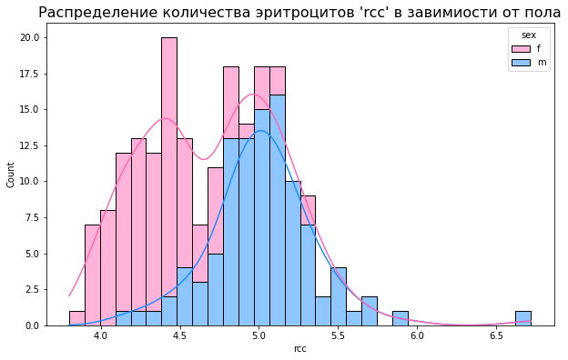

```python
# Построим гистограмму
plt.figure(figsize=(10, 6))
sns.histplot(
    data=df_ais,
    x="rcc",
    hue="sex",                     # Разделение по полу
    kde=True,                      # Добавление кривой плотности
    bins=30,                       # Количество интервалов
    multiple="stack",              # Накладывание столбцов друг на друга
    palette=['#FF69B4', '#1E90FF'] # Палитра
)
plt.title("Распределение количества эритроцитов 'rcc' в завимиости от пола", fontsize=16)
plt.show()
```

**Вывод:**

- Распределения смещены относительно друг друга. Это говорит о том, что средние значения *rcc* различаются у разных полов. У мужчин (m) уровень эритроцитов в среднем выше, чем у женщин (f).
- Распределение *rcc* у женщин имеет две вершины. Возможно, это влияние вида спорта. Для низкого *rcc* (первая першина) - более "легкие" виды спорта, например, гимнастика, для высокого *rcc* (вторая вершина) - спорт для выносливых (плавание, бег).

#### Распределение *rcc* по видам спорта

Посмотрим, насколько вид спорта влияет на количество эритроцитов отдельно для мужчин и женщин.

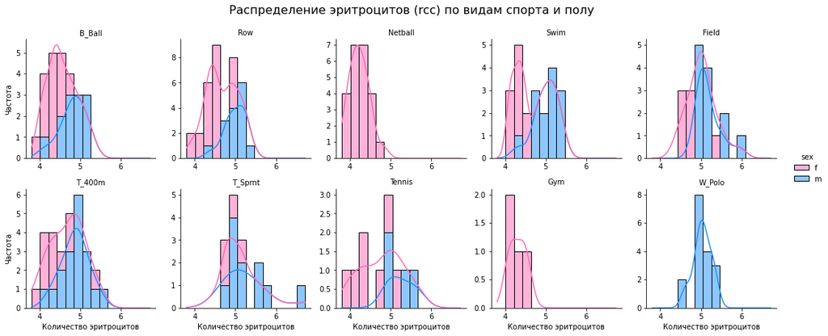

```python
g = sns.displot(
    data=df_ais,
    x='rcc',
    hue='sex',          # разделение по полу
    col='sport',        # сетка по видам спорта
    col_wrap=5,         # по 5 графиков в ряд
    height=3,
    kind='hist',
    kde=True,           # линии плотности для наглядности
    palette=['#FF69B4', '#1E90FF'],
    multiple='stack',   # столбцы накладываются друг на друга
    facet_kws={'sharex': False, 'sharey': False}
)

g.fig.suptitle("Распределение эритроцитов (rcc) по видам спорта и полу", y=1.05, fontsize=16)
g.set_axis_labels("Количество эритроцитов", "Частота")
g.set_titles("{col_name}") # название вида спорта в заголовках
```

Дополнительно построим ящик с усами (boxplot), так как он наглядно показывает медиану, квартили и выбросы, позволяя сравнить, как физиология (в данном случае уровень эритроцитов) отличается у мужчин и женщин в разных дисциплинах.

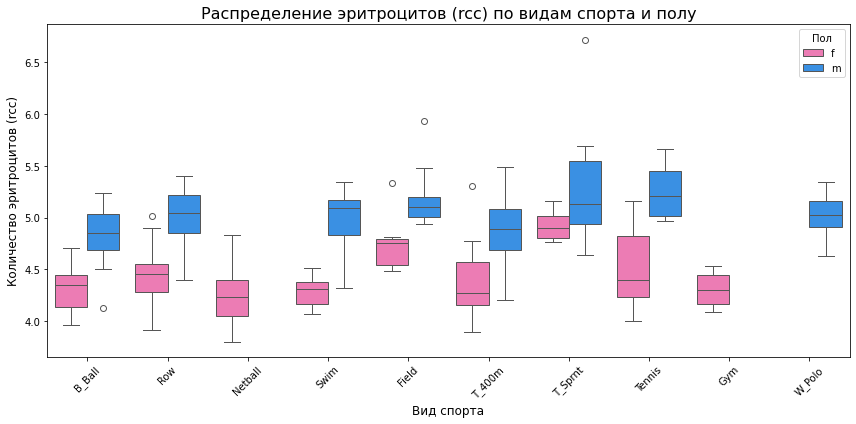

```python
plt.figure(figsize=(12, 6))
sns.boxplot(
    data=df_ais,
    x='sport',
    y='rcc',
    hue='sex',
    palette={'f': '#FF69B4', 'm': '#1E90FF'}
)

plt.title('Распределение эритроцитов (rcc) по видам спорта и полу', fontsize=16)
plt.xlabel('Вид спорта', fontsize=12)
plt.ylabel('Количество эритроцитов (rcc)', fontsize=12)
plt.legend(title='Пол')
plt.xticks(rotation=45)

plt.tight_layout()
plt.show()
```

**Вывод:**

- Наглядно продемонстрировано, что средние значения rcc мужчин расположены выше, чем у женщин. Это физиологическая норма: у мужчин уровень эритроцитов в среднем выше из-за влияния тестостерона.
- Специфика вида спорта: есть виды спорта где разброс показателей шире: бег на 400 метров, (у мужчин и у женщин), теннис (у женщин), спринт (у мужчин).
- Выбросы показывают спортсменов с аномально высоким или низким уровнем rcc для их группы, что может быть связано с их индивидуальностью.

### Зависимость показателей гемоглобина (hg) от пола (sex)

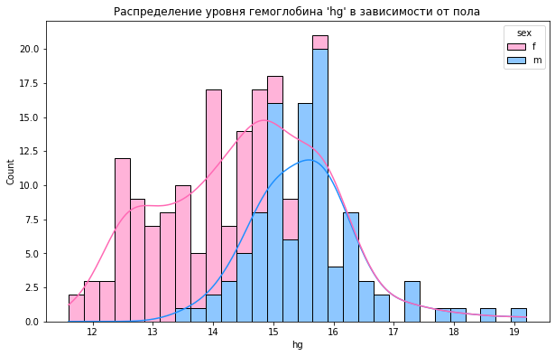

```python
# Построим гистограмму
plt.figure(figsize=(10, 6))
g= sns.histplot(
    data=df_ais,
    x="hg",
    hue="sex",                     # Разделение по полу
    kde=True,                      # Добавление кривой плотности
    bins=30,                       # Количество интервалов
    multiple="stack",              # Накладывание столбцов друг на друга
    palette=['#FF69B4', '#1E90FF'] # Палитра
)
plt.title("Распределение уровня гемоглобина 'hg' в зависимости от пола")
plt.show()
```

**Вывод:**

1. Средние значения гемоглобина у женщин чуть ниже, чем у мужчин - колокол немного левее (пик в районе 14,5-15 г/дл), а "мужской" — правее (пик в районе 16 г/дл).
2. Есть небольшая зона, где показатели женщин совпадают с показателями мужчин, возможно, это также связано с особенносями видов спорта.

#### Распределение hg по видам спорта и полу

Построим диаграмму boxplot для сравнения уровня гемоглобина (hg) в разных видах спорта.

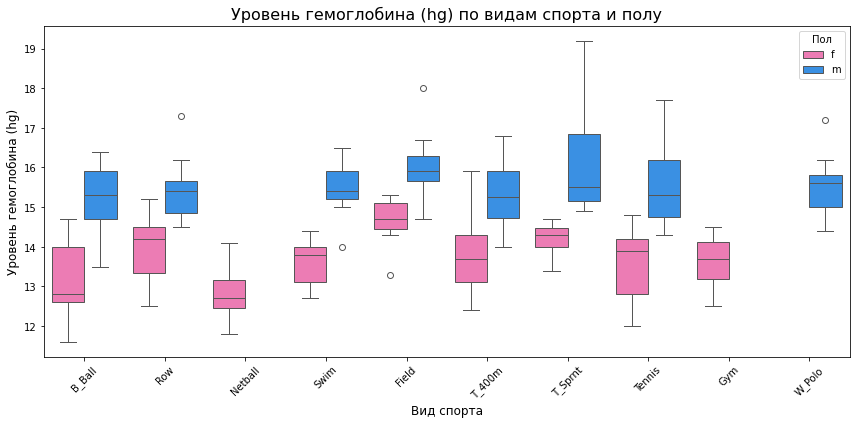

```python
plt.figure(figsize=(12, 6))
sns.boxplot(
    data=df_ais,
    x='sport',
    y='hg',
    hue='sex',
    palette={'f': '#FF69B4', 'm': '#1E90FF'}
)

plt.title('Уровень гемоглобина (hg) по видам спорта и полу', fontsize=16)
plt.xlabel('Вид спорта', fontsize=12)
plt.ylabel('Уровень гемоглобина (hg)', fontsize=12)
plt.legend(title='Пол')
plt.xticks(rotation=45)

plt.tight_layout()
plt.show()
```

Мы видим похожий график, как для эритроцитов, но с более выраженными физиологическими границами. Гемоглобин очень тесно коррелирует с количеством эритроцитов, ведь именно он переносит кислород к тканям. "Мужчины вырываются вперед!"(c) График выглядит очень наглядным.

### Матрица корреляции значимых переменных

Чтоыб установить связь, например, между видом спорта и ростом/весом и т.д. визуализируем тепловую карту матрицы корреляции.

У нас в данных данных есть текстовые столбцы и числа. Коэффициент корреляции **Phi_k** позволяет работать со всеми типами данных одновременно (числа, категории, интервалы), а также может определить как линейные, так и нелинейные зависимости.

Поэтому мспользуем **Phi_k**, передав функции весь датасет целиком.

```python
#вычисляем матрицу корреляции на основе коэффициента phi_k
ais_phik_matrix = df_ais.phik_matrix()
```

```
interval columns not set, guessing: ['rcc', 'wcc', 'hc', 'hg', 'ferr', 'bmi', 'ssf', 'pcBfat', 'lbm', 'ht', 'wt']
```

```python
ais_phik_matrix.head()
```

|  | rcc | wcc | hc | hg | ferr | bmi | ssf | pcBfat | lbm | ht | wt | sex | sport |
| --- | --- | --- | --- | --- | --- | --- | --- | --- | --- | --- | --- | --- | --- |
| rcc | 1.000000 | 0.196799 | 0.864792 | 0.771454 | 0.194307 | 0.000000 | 0.164005 | 0.240210 | 0.440748 | 0.000000 | 0.193075 | 0.691969 | 0.401006 |
| wcc | 0.196799 | 1.000000 | 0.040835 | 0.000000 | 0.292718 | 0.124530 | 0.000000 | 0.000000 | 0.000000 | 0.000000 | 0.156661 | 0.000000 | 0.341068 |
| hc | 0.864792 | 0.040835 | 1.000000 | 0.876144 | 0.205864 | 0.253702 | 0.268432 | 0.324679 | 0.513968 | 0.222603 | 0.427949 | 0.889425 | 0.448498 |
| hg | 0.771454 | 0.000000 | 0.876144 | 1.000000 | 0.336306 | 0.529027 | 0.359840 | 0.518654 | 0.695779 | 0.304949 | 0.560591 | 0.924095 | 0.570199 |
| ferr | 0.194307 | 0.292718 | 0.205864 | 0.336306 | 1.000000 | 0.394524 | 0.000000 | 0.000000 | 0.303499 | 0.000000 | 0.329168 | 0.533161 | 0.268627 |

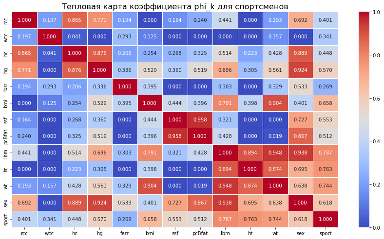

```python
# Визуализируем
plt.figure(figsize=(15, 8))
sns.heatmap(ais_phik_matrix,
            annot=True, # Отображаем численные значения в ячейках карты
            fmt='.3f', # Форматируем значения корреляции: два знака после точки
            cmap='coolwarm', # Устанавливаем цветовую гамму от красного (макс. значение) к синему
            linewidths=0.5, # Форматируем линию между ячейками карты
            cbar=True # Включаем цветовую шкалу
           )
plt.title('Тепловая карта коэффициента phi_k для спортсменов',fontsize=16)
plt.xlabel('')
plt.show()
```

**Вывод:** матрица коорреляции построена, можно анализировать зависимости физиологических параметров.

Интерпретация коэффициента:

- От 0 до 0.3 — слабая корреляция, то есть взаимосвязи практически нет.
- От 0.3 до 0.7 — умеренная корреляция: существует взаимосвязь, но она не очень сильная.
- От 0.7 до 1.0 — сильная корреляция: взаимосвязь между переменными выражена достаточно ярко.
- 0 — корреляции между переменными нет.

Также степень коорреляции отражает цвет ячейки.

### Визуализация зависимости количества эритроцитов (rcc) и гематокрита (hc)

На тепловой карте корреляции phi_k между количеством эритроцитов (rcc) и гематокритом (hc) = 0,865 что говорит об очень сильной положительной связи. Это и понятно, т.к. гематокрит показывает физиологическую способность крови транспортировать кислород (эритроциты).

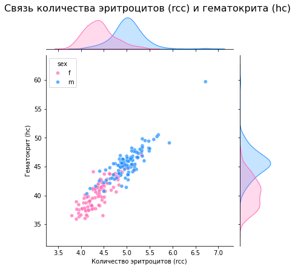

```python
# Создаем совместный график
plt.figure(figsize=(12, 8))
g = sns.jointplot(
    data=df_ais,
    x='rcc',
    y='hc',
    hue='sex',
    palette={'f': '#FF69B4', 'm': '#1E90FF'},
    alpha=0.7,
    kind='scatter'
)
g.fig.suptitle('Связь количества эритроцитов (rcc) и гематокрита (hc)', y=1.02, fontsize=16)
g.ax_joint.set_xlabel('Количество эритроцитов (rcc)')
g.ax_joint.set_ylabel('Гематокрит (hc)')
plt.show()
```

На графике:

- Два практически отдельных облака точек: женщины — ниже и левее, мужчины — выше и правее. Это говорит о сильном влиянии пола на показатели: коэффициент корреляции между полом и rcc= 0,692, а между hc и полом = 0,889.
- Гистограммы сверху и сбоку наглядно показывают «пики» нормы. У женщин пик гематокрита районе 40–42%, у мужчин — 45–48%.
- Выбросы могут быть ошибкой измерения.

### Регрессионный анализ зависимости между ростом (ht) и весом (wt)

На тепловой карте корреляции phi_k между ростом и весом = 0,874, что говорит об очень сильной положительной связи.

Для визуализации подходит инструмент для линейной регрессии lmplot (Linear Model). lmplot вычисляет линейную регрессию, рисует линию тренда и полупрозрачный "коридор" (доверительный интервал). Добавим также разделение по полу.

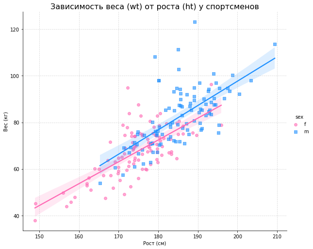

```python
# Строим регрессию с разделением по полу
plt.figure(figsize=(10, 7))
sns.lmplot( # Используем lmplot, чтобы сразу увидеть линии тренда для каждого пола
    data=df_ais,
    x='ht',
    y='wt',
    hue='sex',
    palette={'f': '#FF69B4', 'm': '#1E90FF'},
    markers=["o", "s"], # Кружки для женщин, квадраты для мужчин
    scatter_kws={'alpha':0.6}, # Прозрачность точек
    height=7, aspect=1.2
)

plt.title('Зависимость веса (wt) от роста (ht) у спортсменов', fontsize=16)
plt.xlabel('Рост (см)')
plt.ylabel('Вес (кг)')
plt.grid(True, linestyle='--', alpha=0.5)
```

### Влияние вида спорта (sport) на безжировую массу тела (lbm)

Безжировая масса тела — это общий вес минус вес жира. У элитных атлетов она напрямую коррелирует с силой и выносливостью.

Сначала посмотрим общие показатели для обоих полов.

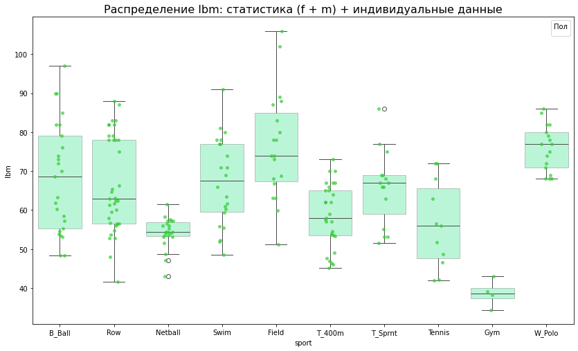

```python
plt.figure(figsize=(14, 8))

# Рисуем прозрачные ящики
sns.boxplot(data=df_ais, x='sport', y='lbm',
            color='#00FF7F', boxprops=dict(alpha=.3))

# Накладываем точки (каждый атлет)
sns.stripplot(data=df_ais, x='sport', y='lbm',
              color='#32CD32',
              dodge=True, alpha=0.7, jitter=True)

# Убираем дублирование легенды
handles, labels = plt.gca().get_legend_handles_labels()
plt.legend(handles[0:2], labels[0:2], title='Пол')

plt.title('Распределение lbm: статистика (f + m) + индивидуальные данные', fontsize=16)
plt.show()
```

**На графике:**

- Самый высокий показатель - у водного поло (W_Polo). Возможно, это сочетание нагрузки и влияния среды - нужно преодолевать сопротивление воды. Этот вид спорта сочетает в себе силу (броски, борьба в воде) и выносливость. Всё это стимулирует развитие мощной мышечной массы.
- Также высокий показатель lbm у легкой атлетики - для скорости нужна легкость и мышечная масса.
- Самый низкий - у гимнастики (Gym) - здесь требуется легкость и изящность.

Посмотрим значения показателя в разделении по полу.

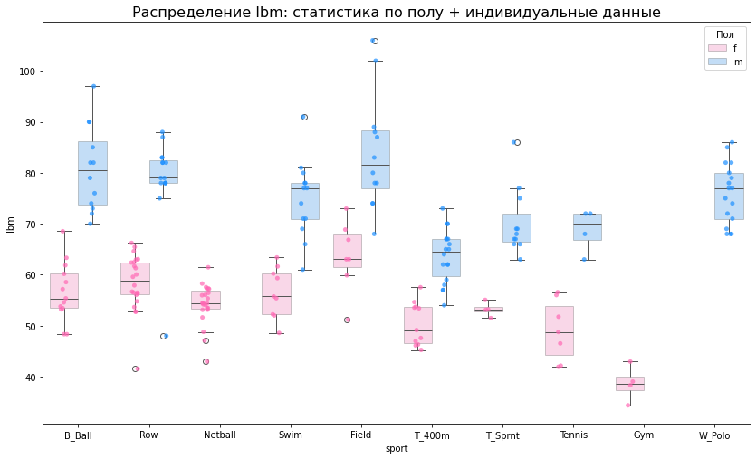

```python
plt.figure(figsize=(14, 8))

# Рисуем прозрачные ящики
sns.boxplot(data=df_ais, x='sport', y='lbm', hue='sex',
            palette={'f': '#FF69B4', 'm': '#1E90FF'}, boxprops=dict(alpha=.3))

# Накладываем точки (каждый атлет)
sns.stripplot(data=df_ais, x='sport', y='lbm', hue='sex',
              palette={'f': '#FF69B4', 'm': '#1E90FF'},
              dodge=True, alpha=0.7, jitter=True)

# Убираем дублирование легенды
handles, labels = plt.gca().get_legend_handles_labels()
plt.legend(handles[0:2], labels[0:2], title='Пол')

plt.title('Распределение lbm: статистика по полу + индивидуальные данные', fontsize=16)
plt.show()
```

**На графике:** Видим разрыв между полами. Разрыв по мышечной массе между мужчинами и женщинами заметно ощутим, что логично.

Посчитаем средний LBM для каждого вида спорта и пола в виде таблицы, чтобы увидеть точные цифры.

```python
#Группируем данные по спорту и полу, считаем среднее для lbm
lbm_table = df_ais.groupby(['sport', 'sex'])['lbm'].mean().unstack()
# Считаем разницу между полами
lbm_table['delta'] = lbm_table['m'] - lbm_table['f']

# Добавляем общее среднее
lbm_table['Total Average'] = df_ais.groupby('sport')['lbm'].mean()

# Сортируем по общему среднему (
lbm_table = lbm_table.sort_values(by='Total Average', ascending=False)

display(lbm_table.round(2))
```

| sex sport | f | m | delta | Total Average |
| --- | --- | --- | --- | --- |
| Field | 63.69 | 83.92 | 20.23 | 76.46 |
| W_Polo | NaN | 75.94 | NaN | 75.94 |
| B_Ball | 56.66 | 80.83 | 24.17 | 68.26 |
| Swim | 56.50 | 74.92 | 18.43 | 67.39 |
| Row | 58.42 | 78.67 | 20.25 | 66.63 |
| T_Sprnt | 53.21 | 70.27 | 17.06 | 65.72 |
| T_400m | 50.38 | 63.61 | 13.23 | 58.59 |
| Tennis | 49.10 | 68.75 | 19.65 | 56.25 |
| Netball | 54.26 | NaN | NaN | 54.26 |
| Gym | 38.66 | NaN | NaN | 38.66 |

**Вывод:** Самая большая разница между мужчинами и женщинами для показателя lbm - в баскетболе. Баскетбол — вид спорта, где важен рост и разница в среднем росте (а значит, и в мышечной массе) между мужчинами-баскетболистами и женщинами-баскетболистками велика. Самый низкий разрыв в видах спорта, где требуется быстрота и легкость - спринт, бег на 400 метром.

## Машинное обучение (ML)

Построим 2 модели для обучения на подмножестве данных AIS c помощью разных алгоритмов, и сравним их. Возьмем влияние роста на вес. В дальнейшем модели можно будет применять для прогнозирования.

### Разделение выборки на обучающую и валидационную

```python
## Разделяем данные
X = df_ais[['ht']] # матрица признаков
y = df_ais['wt']   # вектор с целевой переменной
```

```python
# 2. Разделяем на обучающую и валидационную выборки
# test_size=0.2 - 20% данных пойдет на проверку, 80% - на обучение
# random_state=42 гарантирует, что при каждом запуске разделение будет одинаковым
X_train, X_test, y_train, y_test = train_test_split(X, y, test_size=0.2, random_state=42)
```

```python
display(f"Размер обучающей выборки: {len(X_train)}")
display(f"Размер валидационной выборки: {len(X_test)}")
```

```
'Размер обучающей выборки: 161'
```

```
'Размер валидационной выборки: 41'
```

### Алгоритм LinearRegression (Линейная регрессия)

Принцип работы: ищет одну идеальную прямую линию (или плоскость), которая проходит максимально близко ко всем точкам. Метод очень чувствителен к выбросам, требует масштабирования и кодирования категорий.

```python
# Создаем объект модели
lr_model=model = LinearRegression()
```

```python
# Передаем модели подготовленную порцию данных (train-выборку)
# Модель обучается и строит взаимосвязи между признаками
lr_model.fit(X_train, y_train)
```

```
LinearRegression()
```

```python
# Делаем предсказания на тестовых данных и сохраняем предсказанные значения
y_pred = lr_model.predict(X_test)
```

Оценим качество результатов.

```python
mae = mean_absolute_error(y_test, y_pred)
rmse = np.sqrt(mean_squared_error(y_test, y_pred))
r2 = r2_score(y_test, y_pred)

print(f"Средняя ошибка (MAE): {mae:.2f} кг")
print(f"Квадратичная ошибка (RMSE): {rmse:.2f} кг")
print(f"Точность (R² score): {r2:.2f}")
```

```
Средняя ошибка (MAE): 6.92 кг
Квадратичная ошибка (RMSE): 9.39 кг
Точность (R² score): 0.60
```

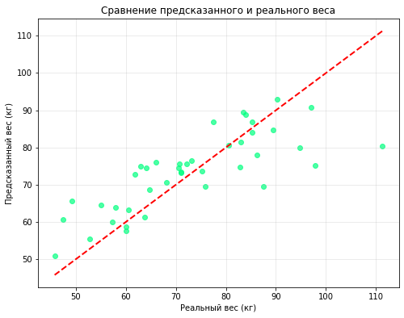

```python
plt.figure(figsize=(8, 6))
plt.scatter(y_test, y_pred, color='#00FF7F', alpha=0.7)
plt.plot([y_test.min(), y_test.max()], [y_test.min(), y_test.max()], 'r--', lw=2) # Идеальная линия

plt.title('Сравнение предсказанного и реального веса')
plt.xlabel('Реальный вес (кг)')
plt.ylabel('Предсказанный вес (кг)')
plt.grid(True, alpha=0.3)
plt.show()
```

### Алгоритм RandomForestRegressor

RandomForestRegressor более сложнный, используется логика ветвления (деревья). Данные разбиваются на группы (листья) и усредняется вес внутри этих групп. Может использоваться любой вид связи (нелинейный, зигзаги, ступеньки). Устоййчив к выбросам, почти не требует подготовки.

```python
# # Создаем объект модели (100 деревьев)
rf_model = RandomForestRegressor(n_estimators=100, random_state=42)
```

```python
# Обучаем
rf_model.fit(X_train, y_train)
```

```
RandomForestRegressor(random_state=42)
```

```python
# # Делаем предсказания на тестовых данных и сохраняем предсказанные значения
y_pred_rf = rf_model.predict(X_test)
```

```python
mae = mean_absolute_error(y_test, y_pred_rf)
rmse = np.sqrt(mean_squared_error(y_test, y_pred_rf))
r2 = r2_score(y_test, y_pred_rf) # или rf_model.score(X_test, y_test)

print(f"Средняя ошибка (MAE): {mae:.2f} кг")
print(f"Квадратичная ошибка (RMSE): {rmse:.2f} кг")
print(f"Точность (R² score): {r2:.2f}")
```

```
Средняя ошибка (MAE): 7.95 кг
Квадратичная ошибка (RMSE): 10.85 кг
Точность (R² score): 0.47
```

### Улучшение качества модели

Улучшим нашу модель на основе алгоритма RandomForestRegressor. Применим проектирование признаков (Feature Engineering)- добавим дополнительно признак "пол".

```python
## Разделяем данные
X = df_ais[['ht','sex']] # матрица признаков
y = df_ais['wt']   # вектор с целевой переменной
```

```python
# заменим категории на числа
X_rf = X.copy()
X_rf['sex'] = X_rf['sex'].map({'f': 0, 'm': 1})
```

```python
# 2. Разделяем на обучающую и валидационную выборки
# test_size=0.2 - 20% данных пойдет на проверку, 80% - на обучение
# random_state=42 гарантирует, что при каждом запуске разделение будет одинаковым
X_train, X_test, y_train, y_test = train_test_split(X_rf, y, test_size=0.2, random_state=42)
```

```python
display(f"Размер обучающей выборки: {len(X_train)}")
display(f"Размер валидационной выборки: {len(X_test)}")
```

```
'Размер обучающей выборки: 161'
```

```
'Размер валидационной выборки: 41'
```

```python
rf_model = RandomForestRegressor(n_estimators=100, random_state=42)
```

```python
rf_model.fit(X_train, y_train)
```

```
RandomForestRegressor(random_state=42)
```

```python
y_pred_rf = rf_model.predict(X_test)
```

```python
mae = mean_absolute_error(y_test, y_pred_rf)
rmse = np.sqrt(mean_squared_error(y_test, y_pred_rf))
r2 = r2_score(y_test, y_pred_rf)

print(f"Средняя ошибка (MAE): {mae:.2f} кг")
print(f"Квадратичная ошибка (RMSE): {rmse:.2f} кг")
print(f"Точность (R² score): {r2:.2f}")
```

```
Средняя ошибка (MAE): 7.03 кг
Квадратичная ошибка (RMSE): 9.80 кг
Точность (R² score): 0.57
```

**Вывод:** Результат чуть лучше, но все равно точность алгоритма RandomForest (0.57) хуже, чем линейная регрессия (0.60).

Причины:

- Мало признаков: используем всего два признака — рост и пол. Связь роста и веса в природе очень близка к прямой линии. Линейная регрессия идеально «видит» эту прямую, а RandomForest пытается строить сложные ступеньки там, где они не нужны.
- Мало данных - 202 записи. Для «Леса» этого мало — он переобучается.
- Линейность данных: Если зависимость простая (чем выше рост, тем больше вес), простая математика всегда побеждает сложную логику деревьев.

# Финальный вывод по проекту AIS

В проекте использованы классические данные **AIS (Australian Institute of Sport)**, в которых собраны показатели крови и параметры тела элитных спортсменов (202 записи).

### 1. Исследовательский анализ данных (EDA)

Визуализация данных (*hist, kdeplot, boxplot*) продемонстрировала:

- **Физиологические различия между полами:** У мужчин показатели крови (эритроциты, гемоглобин) и безжировая масса тела ($lbm$) стабильно выше, чем у женщин, во всех представленных дисциплинах.
- **Специфика видов спорта:** Самые высокие антропометрические показатели (рост, вес) зафиксированы у игроков в водное поло и баскетбол, что объясняется спецификой отбора. Самые низкие показатели наблюдаются в гимнастике.
- **Взаимосвязь признаков:** Корреляционный анализ выявил сверхсильную линейную связь между суммой кожных складок (**ssf**) и процентом подкожного жира (**pcBfat**).

### 2. Результаты машинного обучения

В ходе работы были построены и протестированы две регрессионные модели для предсказания веса спортсмена на основе его роста:

- **Линейная регрессия (Linear Regression):** показала лучший результат. Благодаря строгой линейной зависимости веса от роста, простая математическая модель лучше обобщает данные на небольшой выборке атлетов.
- **RandomForestRegressor:** показал чуть меньшую точность. Это связано с риском переобучения на малом объеме данных и тем, что алгоритмы на основе деревьев по своей природе ищут разрывы (пороги), в то время как в зависимости роста и веса их практически нет.

### 3. Заключение и рекомендации

Проект продемонстрировал, что для качественного предсказания веса недостаточно только роста. Ошибка в **6.9–7.0 кг** является существенной для профессионального спорта.

**Рекомендации по улучшению модели:**

1. **Расширение признаков:** Включение в модель показателей безжировой массы ($lbm$) или суммы кожных складок ($ssf$).
2. **Учет категорий:** Использование переменной вида спорта (`sport`) через кодирование (One-Hot Encoding).